# Results of my Master’s Thesis

Author

Simon Knapstein

Published

October 29, 2025

# Opium Cultivation

I expected a positive difference-in-difference effect for districts with pre-takeover opium poppy cultivation.

In general, I defined a district as poppy-cultivating if UNODC estimates indicated a cultivation area greater than 0 hectares in 2020.

**Yearly DiD**

[output not shown]

The variables ‘treated’ and ‘post’ have been removed because of collinearity.

**Yearly EvSt**

Poppy districts are defined as every district > 0 ha poppy cultivation.

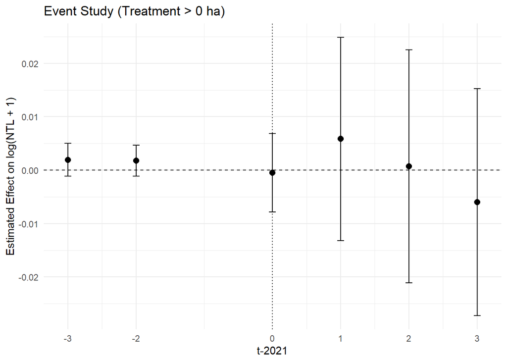

To test wether wether the intensity of poppy cultivation per district played a role I tested different definitions of poppy cultivation by varying the cutoff for when the binary treatment variable equals one. For the relative cutoffs, I divided the absolute poppy cultivation area of each district by its area of irrigated land.

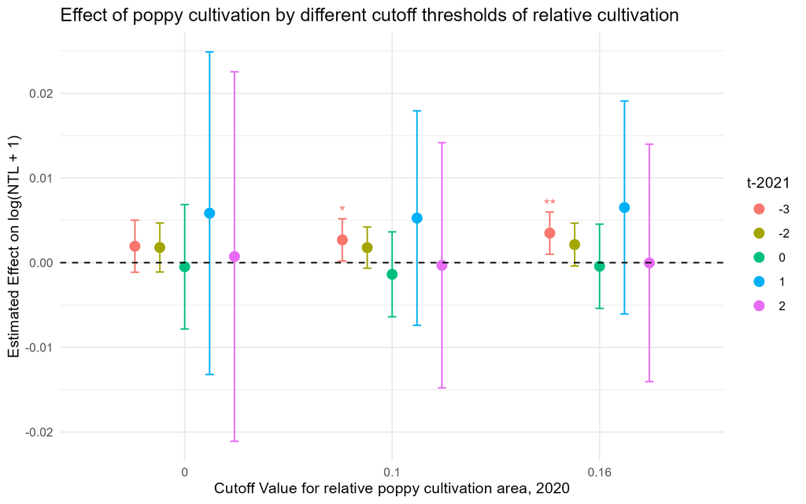

**Quarterly EvSt**

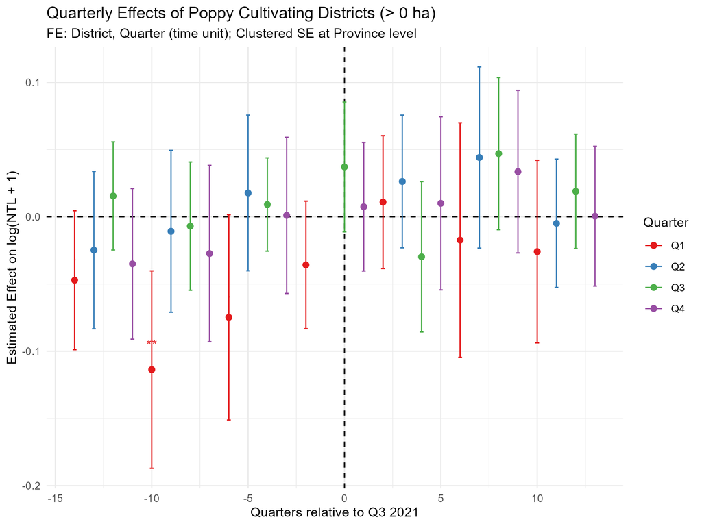

# Poppy Ban

On April 3 2022 the de-facto government announced a ban on Opium poppy cultivation with a two-month grace period covering the ongoing harvest. Because of the grace period, it can be argued that the 2022 harvest was largely unaffected even though the ban was already announced. Farmers shifted towards wheat cultivation from the beginning of the sowing season around October and November 2022 . Because 80% of the opium harvest is sold by farmers within the same year it is likely that economic effects are seen in the next harvest season of 2023 .

Hence, I test two alternative event times of the ban: 2022 and in 2023.

I expect a negative difference-in-diffrence effect on districts which cultivated opium poppy before the ban (became effective).

**Yearly DiD**

```
                        did_ban_22
Dependent Var.:             ln_ntl

treated x post = 1 0.0016 (0.0084)
Fixed-Effects:     ---------------
district_fe                    Yes
time_fe                        Yes
__________________ _______________
S.E.: Clustered          by: GID_1
R2                         0.97884
Observations                   656
---
Signif. codes: 0 '***' 0.001 '**' 0.01 '*' 0.05 '.' 0.1 ' ' 1
```

**Yearly EvSt**

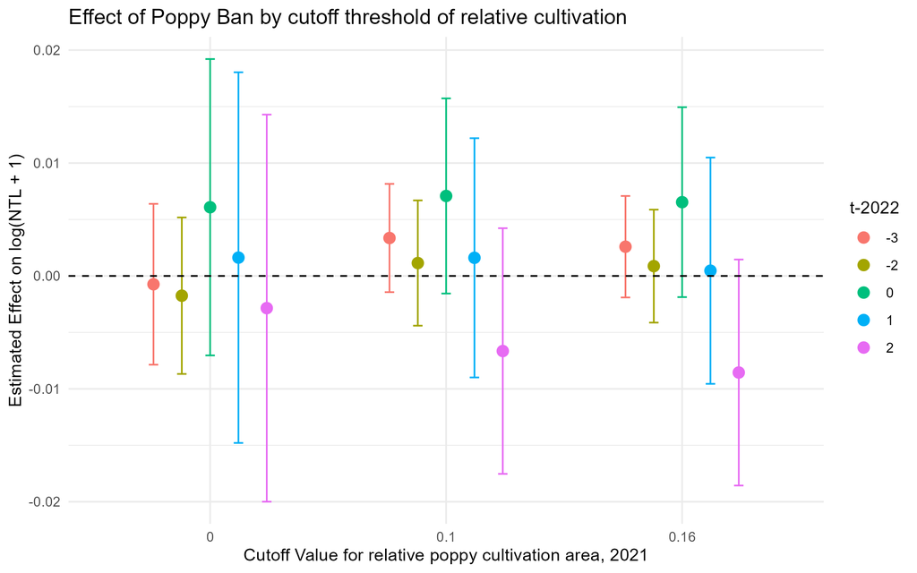

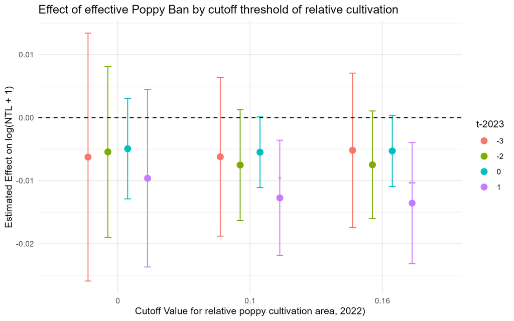

**Quarterly EvSt**

For 2022 ban:

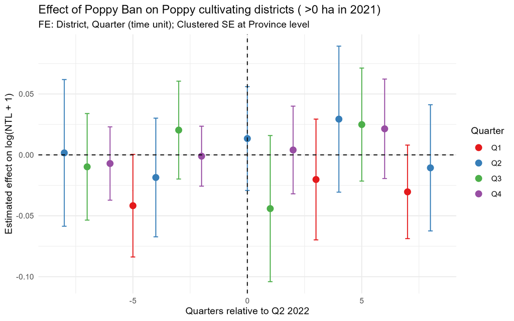

For 2023 “effective” ban

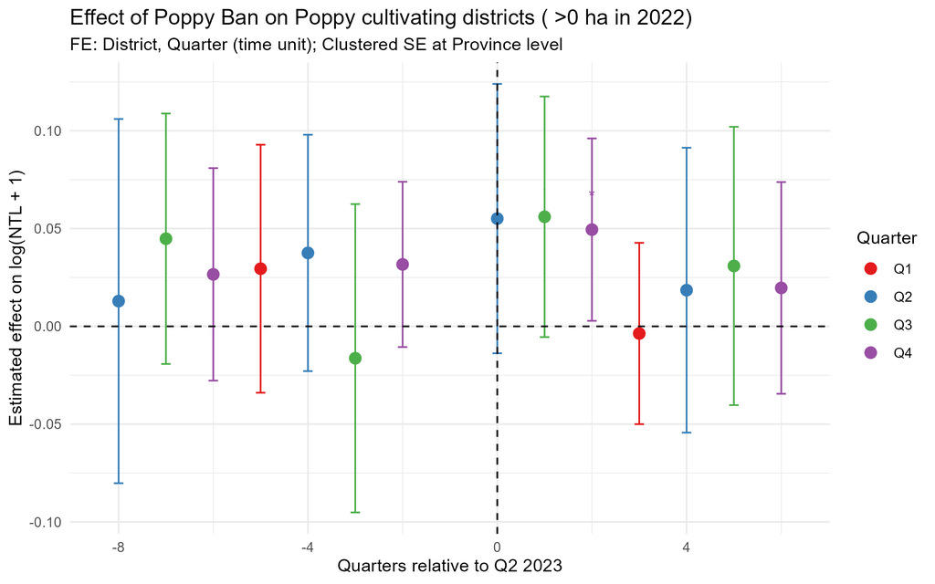

# Taliban Control

During the NATO mission, Afghanistan was never fully under the control of the Afghan government and its allies. I expect a positive difference-in-differences effect for districts that were already under Taliban control as of April 8, 2021 as I assumed these districts would experience less (economic) disruption.

**Yearly DiD**

[output not shown]

Dependent Var.: ln_ntl

**Yearly EvSt**

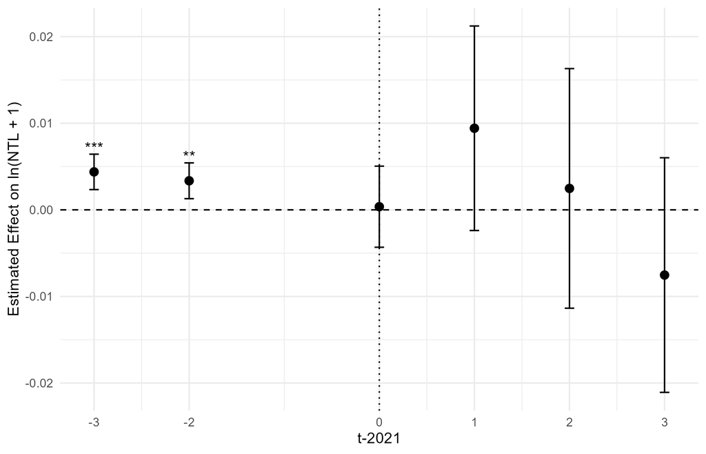

**Quarterly EvSt**

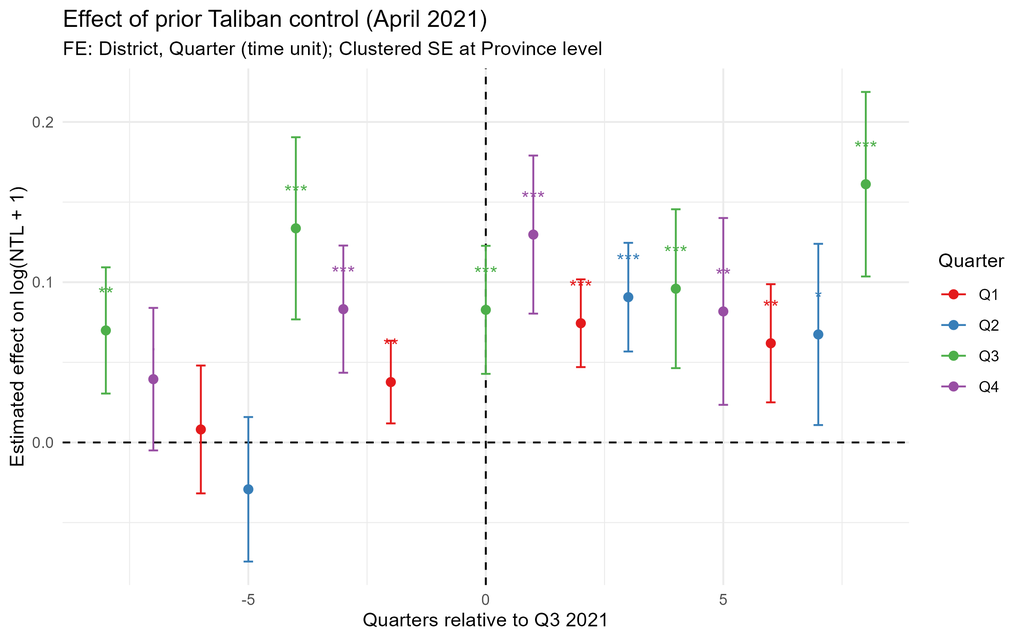

# NATO Installations

The NATO mission had installations in various districts across Afghanistan. I expect a negative difference-in-differences effect for districts with prior NATO installations, as these areas are likely to experience a greater change in the local economy due to the withdrawal of foreign forces and aid.

**Yearly DiD**

[output not shown]

Dependent Var.: ln_ntl

**Yearly EvSt**

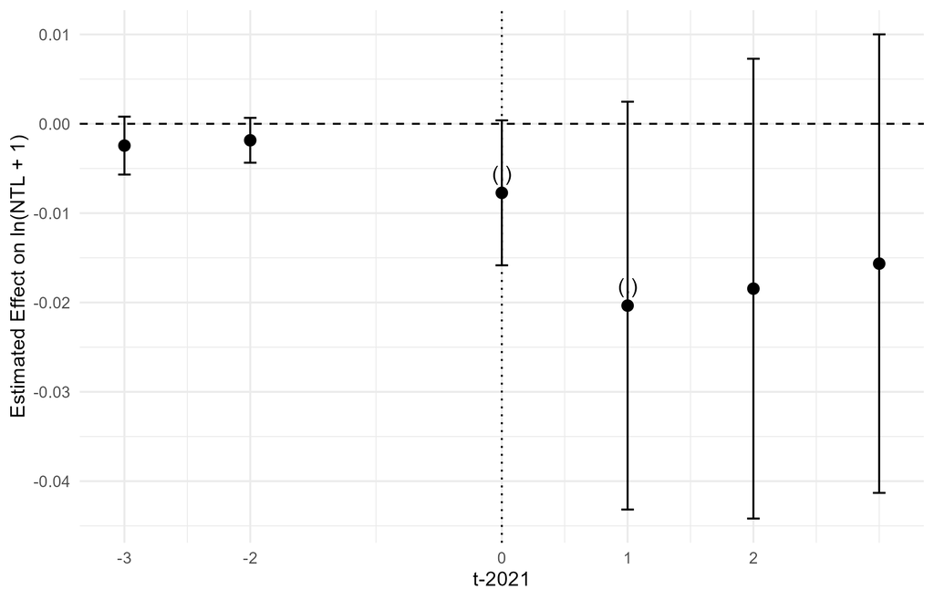

The negative effects in 2021 and 2022 are significant at the 10% level.

[interactive chart not shown]

**Quarterly EvSt**

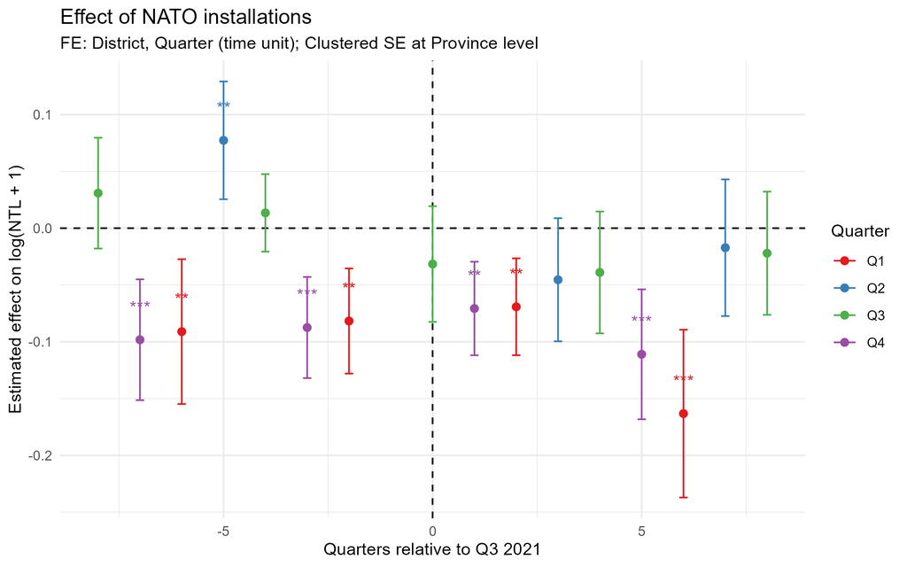